# Homework 4

Innocent Abaa

2023-09-24

# 1 Exercise 3.14

Generate 200 random observations from the 3-dimensional multivariate normal distribution having mean vector $\boldsymbol{\mu} = (0, 1, 2)$ and covariance matrix
$$\boldsymbol{\Sigma} =
\begin{bmatrix}
1.0 & -0.5 & 0.5 \\
-0.5 & 1.0 & -0.5 \\
0.5 & -0.5 & 1.0
\end{bmatrix}$$
using the Choleski factorization method. Use the R pairs plot to graph an array of scatter plots for each pair of variables. For each pair of variables, (visually) check that the location and correlation approximately agree with the theoretical parameters of the corresponding bivariate normal distribution.

$\textbf{Solution}$

```r
rmvn.Choleski <-
function(n, mu, Sigma) {
# generate n random vectors from MVN(mu, Sigma)
# dimension is inferred from mu and Sigma
d <- length(mu)
Q <- chol(Sigma) # Choleski factorization of Sigma
Z <- matrix(rnorm(n*d), nrow=n, ncol=d)
X <- Z %*% Q + matrix(mu, n, d, byrow=TRUE)
X
}

Sigma <- matrix(c(1, -.5, .5, -.5, 1,
-.5, .5, -.5, 1), 3, 3)
mu <- c(0, 1, 2)
x <- rmvn.Choleski(200, mu, Sigma)
colMeans(x)
```

```
## [1] -0.04986239  0.93192078  2.09490757
```

```r
cor(x)
```

```
##            [,1]       [,2]       [,3]
## [1,]  1.0000000 -0.4237688  0.5130436
## [2,] -0.4237688  1.0000000 -0.5010921
## [3,]  0.5130436 -0.5010921  1.0000000
```

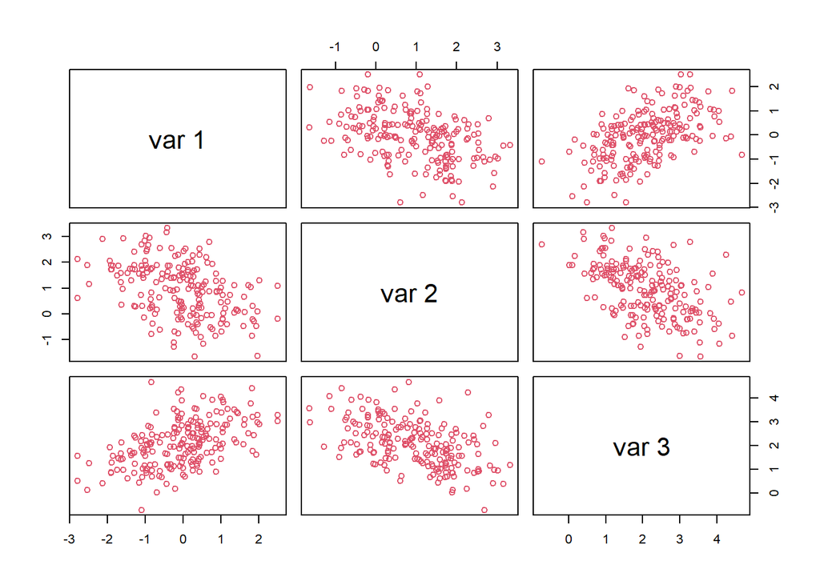

```r
pairs(x, col =2)
```

$\textbf{Comment}$

Based on the pairs plot provided, it can be observed that the distribution centers align closely with the parameters represented by µ, and the correlations also exhibit a similar alignment with the parameters represented by Σ.

# 2 Exercise 3.15

Write a function that will standardize a multivariate normal sample for arbitrary n and d. That is, transform the sample so that the sample mean vector is zero and sample covariance is the identity matrix. To check your results, generate multivariate normal samples and print the sample mean vector and covariance matrix before and after standardization.

$\textbf{Solution}$

The method employed for generating multivariate normal samples via eigen-decomposition involves the following transformation formula:
$$X = Z \Sigma^{1/2} + J\mu^T,$$
where $\Sigma^{1/2}$ is obtained from the eigen-decomposition as $\Sigma^{1/2} = P\Lambda^{1/2}P^T$.

To standardize the sample, an alternative formula is applied:
$$Y = (X - J\mu^T)\Sigma^{-1/2},$$
where $\Sigma^{-1/2}$ is computed using the same eigen-decomposition method, resulting in $\Sigma^{-1/2} = P\Lambda^{-1/2}P^T$.

For standardizing the sample with estimated mean and covariance, a slightly different formula is used:
$$Y = (X - J\bar{X}^T)S^{-1/2},$$
where $\bar{X}$ represents the vector of sample means, and $S^{-1/2}$ is calculated in a manner similar to how $\Sigma^{-1/2}$ is computed.

We generate a multivariate normal sample using from Choleski factorization method.So, here will use $\Sigma$ the $\mu$ values we used in $\textbf{Exercise 3.14}$

```r
x <- rmvn.Choleski(200, mu, Sigma)
colMeans(x)
```

```
## [1] -0.01646414  1.01375837  1.97791070
```

```r
cor(x)
```

```
##            [,1]       [,2]       [,3]
## [1,]  1.0000000 -0.4766247  0.4886990
## [2,] -0.4766247  1.0000000 -0.4814204
## [3,]  0.4886990 -0.4814204  1.0000000
```

Now, we write a function to standardize our multivariate normal sample.

```r
standardize <-
function(x) {
if (is.vector(x))
return(scale(x))
x <- as.matrix(x)
d <- ncol(x)
n <- nrow(x)
S <- cov(x)
m <- colMeans(x)
means <- matrix(m, n, d, byrow = TRUE)
ev <- eigen(S, symmetric = TRUE)
lambda <- ev$values
V <- ev$vectors
R <- V %*% diag(sqrt(1/lambda)) %*% t(V)
Z <- (x - means) %*% R
return(Z)
}
```

Next, let’s standardize X with our “Standardize” function.

```r
Z <- standardize(x)
head(Z)
```

```
##            [,1]       [,2]        [,3]
## [1,] -0.4049643 -0.1953385  1.24829151
## [2,]  0.6649379 -0.1267859  0.59972710
## [3,]  1.3265545  0.2262684 -0.90269956
## [4,]  0.3843453 -0.7375887  1.12043283
## [5,] -1.6821038 -0.6871873 -0.09631309
## [6,]  0.8919285 -0.5924155  0.15020368
```

Sample mean vector and covariance matrix after standardization.

```r
colMeans(Z) #Sample mean vector
```

```
## [1] -1.720846e-17 -9.051787e-17 -3.184952e-17
```

```r
cov(Z)       #covariance matrix
```

```
##               [,1]          [,2]          [,3]
## [1,]  1.000000e+00 -5.698409e-17 -3.302962e-17
## [2,] -5.698409e-17  1.000000e+00  3.311153e-16
## [3,] -3.302962e-17  3.311153e-16  1.000000e+00
```

```r
mu.0=rep(0,3)
all.equal(colMeans(Z), mu.0, check.attributes=FALSE)
```

```
## [1] TRUE
```

This shows that the mean of our standardized data is equal to $μ=(0,0,0)^t$ up to the accuracy of the machine representation as expected.

```r
I_3=diag(3)
all.equal(cov(Z), I_3, check.attributes=FALSE)
```

```
## [1] TRUE
```

This shows that the covariance of our standardized data is equal to $I_3$ up to the accuracy of the machine representation as expected.

$\textbf{Comment}$

The sample mean vector of the standardized sample is (approximately) the zero vector, and the sample covariance of the standardized sample is (approximately) the identity matrix.

# 3 Exercise 3.16

Efron and Tibshirani discuss the bootstrap test score data on 88 students who took examinations in five subjects [91, Table 7.1], [194, Table 1.2.1]. Each row of the data frame is a set of scores $(x_{i1}, \ldots, x_{i5})$ for the $i$-th student.To standardize the scores by type of exam, we can standardize the bivariate samples $(X_1, X_2)$ (closed book) and the trivariate samples $(X_3, X_4, X_5)$ (open book). After standardization, we can compute the covariance matrix of the transformed sample of test scores.

$\textbf{Solution}$

```r
library(bootstrap)
score <- scor
close.dat <- score[,1:2]
open.dat <- score[,3:5]
cbook <- as.matrix(close.dat)
obook <- as.matrix(open.dat)
```

Next, let’s standardize cbook and obook with our “Standardize” function.

```r
# Standardize the scores
cstd <- standardize(cbook)
ostd <- standardize(obook)

# Combine the standardized scores
K <- cbind(cstd, ostd)

colMeans(K)
```

```
## [1]  1.301043e-16 -2.589469e-16 -4.802030e-17  9.391162e-17  9.004792e-17
```

```r
# Compute the covariance matrix and round to 5 decimal places
round(cov(K), 5)
```

```
##         [,1]    [,2]    [,3]    [,4]    [,5]
## [1,] 1.00000 0.00000 0.35315 0.17654 0.19225
## [2,] 0.00000 1.00000 0.37329 0.25521 0.20976
## [3,] 0.35315 0.37329 1.00000 0.00000 0.00000
## [4,] 0.17654 0.25521 0.00000 1.00000 0.00000
## [5,] 0.19225 0.20976 0.00000 0.00000 1.00000
```

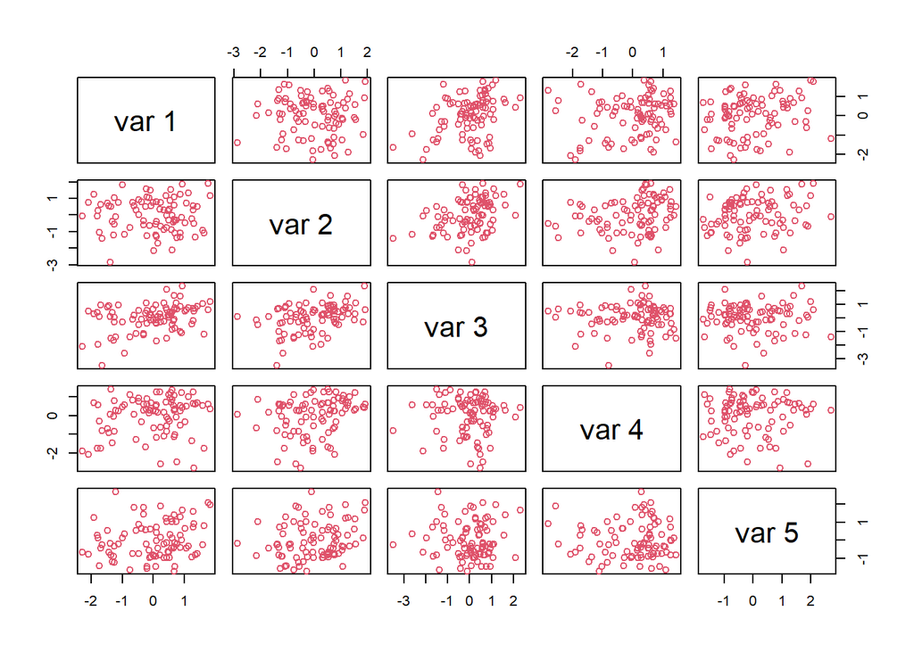

```r
# Create a scatterplot matrix with colors
pairs(K,col=2)
```

```r
mu.0=rep(0,5)
all.equal(colMeans(K), mu.0, check.attributes=FALSE)
```

```
## [1] TRUE
```

This shows that the mean of our standardized bivariate samples is equal to $\boldsymbol{\mu} = (0,0,0,0,0)^T$ up to the accuracy of the machine representation as expected.

# 4 Exercise 3.17

Compare the performance of the Beta generator of Exercise 3.7, Example 3.8, and the R generator . Fix the parameters $a = 2$, $b = 2$, and time each generator on 1000 iterations with a sample size of 5000 (see Example 3.19). Are the results different for different choices of $a$ and $b$?

$\textbf{Solution}$

```r
# Example 3.8 Beta(2,2)
library(rBeta2009)
set.seed(419)
n <- 5000 #sample size
N <- 1000 #iterations
a <- 2
b <- 2


set.seed(419)
system.time(for (i in 1:N)
rbeta(n, a, b), gcFirst=TRUE)
```

```
##    user  system elapsed
##    0.42    0.00    0.42
```

```r
set.seed(419)
system.time(for (i in 1:N) {
u <- rgamma(n, a, 1)
v <- rgamma(n, b, 1)
x <- u / (u + v) } , gcFirst=TRUE)
```

```
##    user  system elapsed
##    1.35    0.03    1.41
```

```r
## The beta function we used for Exercise 3.7
rBETA <- function(n, a, b) {
n <- 1000
k <- 0 #counter for accepted
y <- numeric(n)
while (k < n) {
u <- runif(1)
x <- runif(1) #random variate from g
if (x^(a-1) * (1-x)^(b-1) > u) {
#we accept x
k <- k + 1
y[k] <- x
}
}
return(y)
}


set.seed(419)
system.time(for (i in 1:N)
rBETA(n, a, b), gcFirst=TRUE)
```

```
##    user  system elapsed
##   18.50    2.31   21.10
```

```r
## Exercise 3.7 with Beta(3,2)
a <- 3
b <- 2
set.seed(419)
system.time(for (i in 1:N)
rbeta(n, a, b), gcFirst=TRUE)
```

```
##    user  system elapsed
##    0.35    0.00    0.35
```

```r
set.seed(419)
system.time(for (i in 1:N) {
u <- rgamma(n, a, 1)
v <- rgamma(n, b, 1)
x <- u / (u + v) } , gcFirst=TRUE)
```

```
##    user  system elapsed
##    1.32    0.00    1.33
```

```r
set.seed(419)
system.time(for (i in 1:N)
rBETA(n, a, b), gcFirst=TRUE)
```

```
##    user  system elapsed
##   46.71    0.44   48.52
```

$\textbf{Comment}$

Are the results different for different choices of $a$ and $b$?: $\textbf{Yes}$

Case 1: Example 3.8 Beta(a=2,b=2)

Also,

Case 2: Exercise 3.7 with Beta(a=3,b=2)

# 5 Exercise 3.18

Write a function to generate a random sample from a $W_d(\Sigma, n)$ (Wishart) distribution for $n > d + 1 \geq 1$, based on Bartlett’s decomposition.

$\textbf{Solution}$

```r
rWISH <- function(Sigma, n) {
  d <- nrow(Sigma)
  U <- chol(Sigma)
  y <- matrix(0, d, d)
  for (j in 1:d) {
    for (i in j:d) {
      y[i, j] <- rnorm(1)
    }
    y[j, j] <- sqrt(rchisq(1, n - j + 1))
  }
  A <- y %*% t(y)
  return(t(U) %*% A %*% U)
}

rWish <- function(n, Sigma, nu) {
  w <- replicate(n, rWISH(Sigma, nu))
  return(array(w, c(2, 2, n)))
}

# Example usage:

# 1. Generate a random sample from a Wishart distribution with 1 degree of freedom
sigma <- 6 * diag(6)
n <- 10
rWISH(sigma,n)
```

```
##            [,1]       [,2]       [,3]       [,4]       [,5]       [,6]
## [1,]  34.296751  -6.515224  -2.323291 -16.631341   2.412229  11.911183
## [2,]  -6.515224  42.584455 -14.416085  40.389330   5.201843  -3.318763
## [3,]  -2.323291 -14.416085  44.541395 -18.844223 -10.559328  -8.384549
## [4,] -16.631341  40.389330 -18.844223  64.475438   1.601501   1.119520
## [5,]   2.412229   5.201843 -10.559328   1.601501  55.787889 -14.778251
## [6,]  11.911183  -3.318763  -8.384549   1.119520 -14.778251  57.093148
```

```r
# Example usage:
# 2.Generate 5 random Wishart samples with a covariance matrix 'Sigma' and 100 degrees of freedom
Sigma <- matrix(c(1, 0.5, 0.5, 1), nrow = 2)
samples_high_df <- rWish(5, Sigma, 100)
print(samples_high_df)
```

```
## , , 1
##
##           [,1]     [,2]
## [1,] 107.91896 57.95343
## [2,]  57.95343 89.76336
##
## , , 2
##
##          [,1]     [,2]
## [1,] 98.02856 56.67305
## [2,] 56.67305 90.27381
##
## , , 3
##
##           [,1]      [,2]
## [1,] 100.51755  66.28733
## [2,]  66.28733 113.64953
##
## , , 4
##
##           [,1]     [,2]
## [1,] 101.33586 43.30145
## [2,]  43.30145 89.62230
##
## , , 5
##
##          [,1]     [,2]
## [1,] 98.13743 42.73493
## [2,] 42.73493 75.41611
```